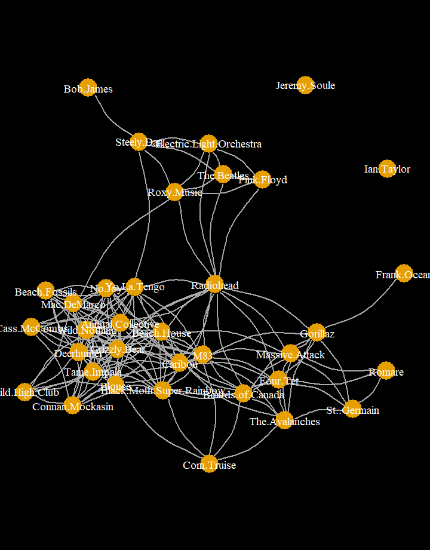

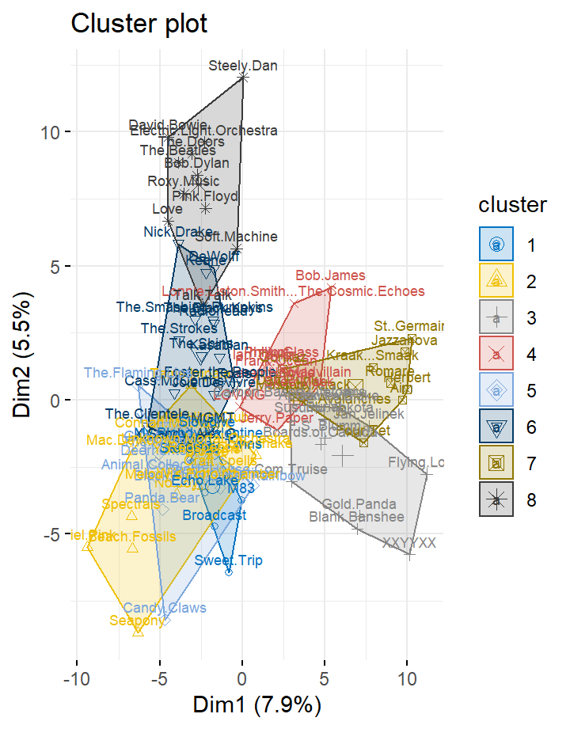

# Week 12.1: Data preparation

### Most common tags of my top 100 artists

This week, I have done something quite cool. For some time, I was thinking of ways to be able to group my artists based on genre. This seemed challenging: Spotify doesn’t provide these features, so I had to think of an alternative. Luckily, the Last FM API does provide us with a way to fetch artist’s tags. Tags are general descriptors of artists. Although I knew how to fetch them, the hard part was being able to group the artists based on these tags. So, I had to develop a few methods of my own.

First things first, what are tags? To give you a better idea of this, on the left you see a table with the most common tags of my top 100 artists. In total, these 100 artists had 275 different tags, and each artist had on average about 50 tags.

As you can see, there are some tags there that are descriptive of my music taste: Indie, alternative, psychedelic, electronic, ambient, chillout, etc. Some tags are general: seen live is a tag that people give to an artist they have seen live, so that has nothing to do with the type of music. As such, I have removed this tag for further analysis.

### Top tags

|  | Frequency | Tag |
| --- | --- | --- |
| 1 | 84 | seen live |
| 2 | 80 | indie |
| 3 | 75 | alternative |
| 4 | 74 | electronic |
| 5 | 68 | experimental |
| 6 | 65 | rock |
| 7 | 62 | pop |
| 8 | 60 | psychedelic |
| 9 | 58 | indie rock |
| 10 | 55 | electronica |

[output cut: 1426 more lines]

# Week 12.2: Jaccard Index

### Using the tags to get a measure for artist similarity + network plot

To show you all of this, I have plotted the similarity matrix for my top 10 artists.

So, what can you do with this data? Visualizations! A network plot is usually used for correlations between variables, but of course it can also be used to show how my artists are grouped.

### Similarity between my top 10 artists

|  | Mac.DeMarco | Grizzly.Bear | Boards.of.Canada | Beach.House | Steely.Dan | Bob.James | Deerhunter | Yo.La.Tengo | Jeremy.Soule | M83 |
| --- | --- | --- | --- | --- | --- | --- | --- | --- | --- | --- |
| Mac DeMarco | 1.00000000 | 0.33870968 | 0.09090909 | 0.21875000 | 0.12820513 | 0.01470588 | 0.36206897 | 0.25714286 | 0.00000000 | 0.15942029 |
| Grizzly Bear | 0.33870968 | 1.00000000 | 0.23214286 | 0.41509434 | 0.16438356 | 0.08196721 | 0.40740741 | 0.39344262 | 0.08888889 | 0.26229508 |
| Boards of Canada | 0.09090909 | 0.23214286 | 1.00000000 | 0.25490196 | 0.08823529 | 0.10000000 | 0.14035088 | 0.21311475 | 0.11764706 | 0.29411765 |
| Beach House | 0.21875000 | 0.41509434 | 0.25490196 | 1.00000000 | 0.14285714 | 0.08928571 | 0.29090909 | 0.37931034 | 0.12820513 | 0.30909091 |
| Steely Dan | 0.12820513 | 0.16438356 | 0.08823529 | 0.14285714 | 1.00000000 | 0.31481481 | 0.10958904 | 0.25000000 | 0.08000000 | 0.12328767 |
| Bob James | 0.01470588 | 0.08196721 | 0.10000000 | 0.08928571 | 0.31481481 | 1.00000000 | 0.05084746 | 0.12698413 | 0.16666667 | 0.06779661 |
| Deerhunter | 0.36206897 | 0.40740741 | 0.14035088 | 0.29090909 | 0.10958904 | 0.05084746 | 1.00000000 | 0.37288136 | 0.07142857 | 0.25862069 |
| Yo La Tengo | 0.25714286 | 0.39344262 | 0.21311475 | 0.37931034 | 0.25000000 | 0.12698413 | 0.37288136 | 1.00000000 | 0.10204082 | 0.34426230 |
| Jeremy Soule | 0.00000000 | 0.08888889 | 0.11764706 | 0.12820513 | 0.08000000 | 0.16666667 | 0.07142857 | 0.10204082 | 1.00000000 | 0.09523810 |
| M83 | 0.15942029 | 0.26229508 | 0.29411765 | 0.30909091 | 0.12328767 | 0.06779661 | 0.25862069 | 0.34426230 | 0.09523810 | 1.00000000 |

### Network plot of artist similarity

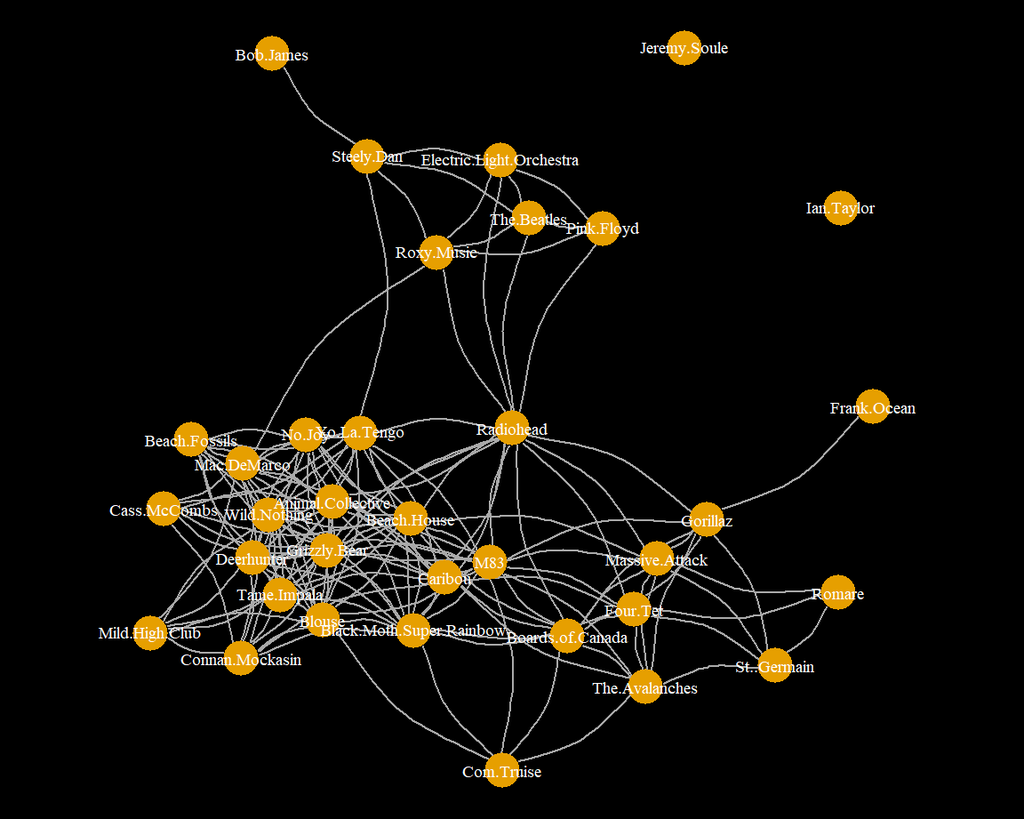

# Week 12.3: K-means Clustering

### Clustering my top 100 artists based on their tags

After a very useful tip from a fellow student (before I even knew that kmeans clustering was part of the homework), he recommended me to use a clustering method: k-means clustering. Much to my surprise, this worked very easily, and actually with quite some good results. I had considered latent class analysis, a method that stems from Psychological testing, but why use scientifically valid methods when a quick and dirty algorithm can do all the work just as well?  
I have tried multiple methods, such as PAM, but for some reason this just didn’t do as good a job as the standard k-means with the Hartigan-Wong algorithm.

Interstingly, we actually see some of the groups that were also visible in the network plot: the seventies artists are grouped nicely together. I don’t listen to this kind of music nearly as much as I used to do however, perhaps I could visualize this at some point as well? This is the cluster at the top, which includes artists like Steely Dan, David Bowie, and Electric Light Orchestra.

The cluster below that is alternative rock, and contains more recent artists. For example, The Strokes, The Black Keys, Kasabian, The Shins, etc. This is where things start to get messy, as this is where we get into the area of bands that are quite similar. I could have chosen to cluster them together in one group, but since these artists constitute the majority of my music listening I decided to seperate them anyways.

For one, there is the psychedelic rock cluster: Tame Impala, Mac DeMarco, Ariel Pink, Homeshake, Unknown Mortal Orchestra. Then there is the more indie and acoustic alternative rock cluster: Grizzly Bear, Yo La Tengo, Beach House, Antlers. The smaller cluster is a group of dream pop and shoegaze artists: Cocteau Twins, Broadcast, My Bloody Valentine, M83.

A little over to the right, there is a cluster in the middle that makes no sense at all. I have not managed to fix this, but this is probably due to the artists being mostly outliers.

The final two clusters are more electronic: St. Germain, Romare, Kraak & Smaak, and Jazzanova are more… jazzy, as the last band implies. Finally, we have the IDM cluster, which is most of the music I have been listening to recently: Aphex Twin, Boards of Canada, Gold Panda, Susumu Yokota.

So what’s next? Connecting the clusters to the spotify features! So far, I have not found that many interesting results. I am positive however that there will be a link. And finally, to answer my research question, I will plot dominant genres over time!

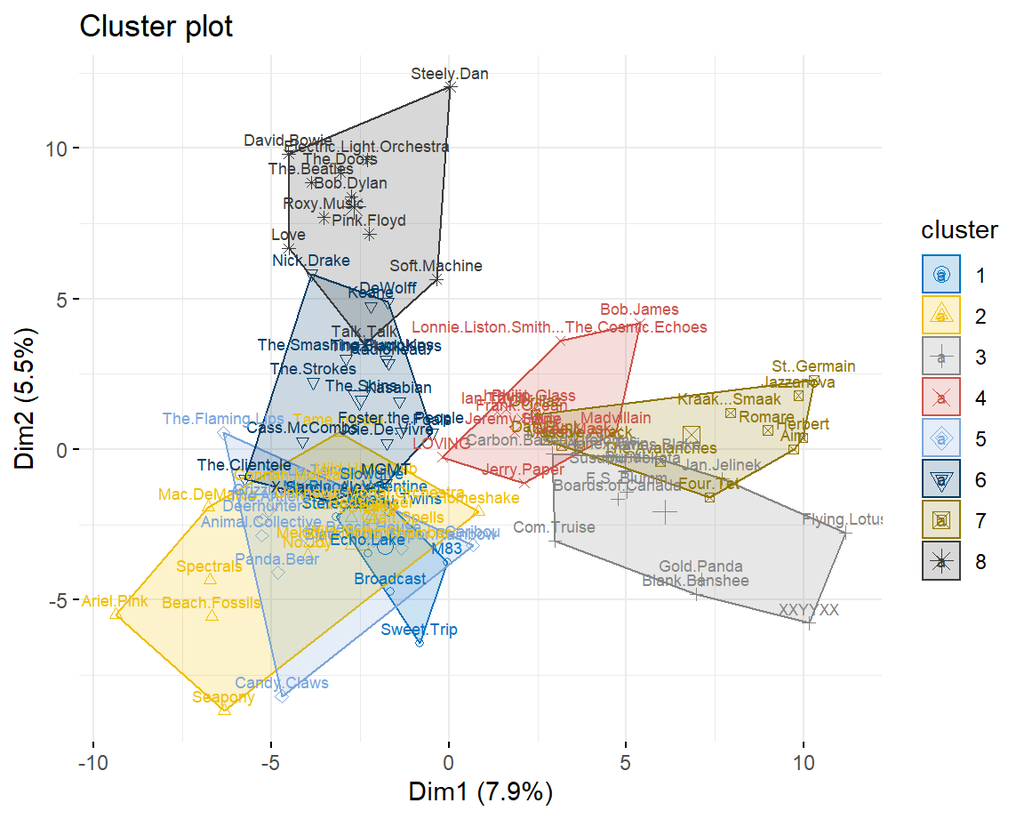